# TP de Probabilités

Irène Gannaz

2017-2018

Ceci est un exemple de document fait avec Rmarkdown. Je vous conseille de l’utiliser pour votre compte-rendu de TP. Pour exécuter un .Rmd, utiliser le bouton ‘Knit’ de Rstudio.

On peut mettre du code qui sera exécuté mais qui n’aparaitra pas dans le compte rendu.

Ensuite on peut aussi mettre du code qui apparaît dans le compte-rendu.

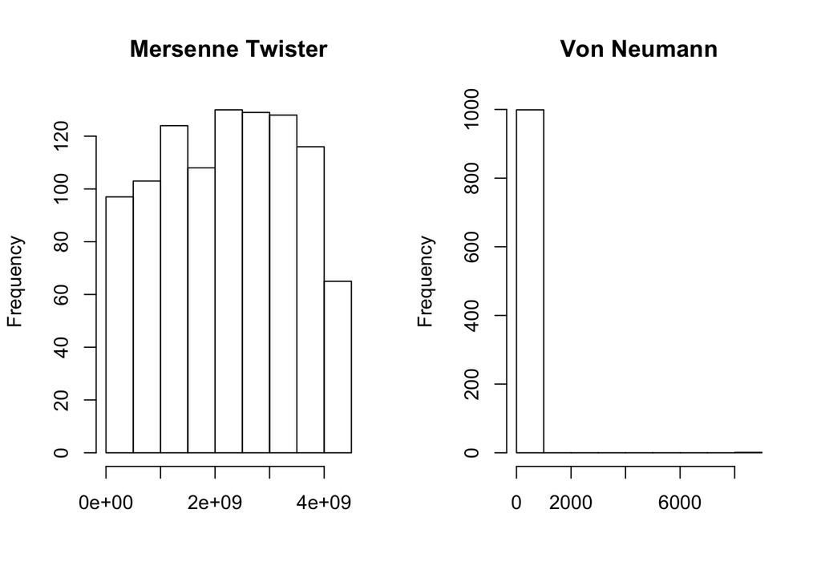

```r
vn <- VonNeumann(Nsimu,Nrepet,sVN)
mt <- MersenneTwister(Nsimu,Nrepet,sMT)

par(mfrow=c(1,2))
hist(mt[,1],xlab='',main='Mersenne Twister')
hist(vn[,1],xlab='',main='Von Neumann')
```

```r
(bit_mt <- binary(mt[1,1]))
```

```
##  [1] 1 0 0 1 1 0 0 1 1 1 0 1 1 0 0 0 0 1 1 1 0 0 1 1 0 0 0 1 0 0 1 1
```

Comme vous pouvez le voir, les retours numériques de R ainsi que les sorties graphiques sont intégrés dans le compte-rendu.

Il est possible de mettre des mots *en italique* ou **en gras**. On peut également faire des listes :

- Item 1
- Item 2
  - sub-item 1
  - sub-item 2

Et des tableaux :

| Permière colonne | Deuxième colonne |
| --- | --- |
| a | x |
| b | y |

Ou mettre des formules : $Aire = \pi\,r^{2}$.